# Partial Correlation

```r
library(dplyr)
```

Partial correlation measures the degree of association between 2 continuous variables, with the effect of a set of controlling variables removed.

$$\space$$

The partial correlation between continuous variable $X$ and continuous variable $Y$, controlling for variable(s) $\mathbf{Z}=\{Z_1,Z_2,Z_3...\}$ (categorical or continuous) is measured by $\text{Cor}\Big[e_X,e_Y\Big]$ - the correlation between $e_X$ and $e_Y$ - where

$$e_X \quad \text{is the residuals from the linear regression } \quad \hat{X} = \beta_0+\beta_1Z_1+\beta_2Z_2+...+e_X$$

and

$$e_Y \quad \text{is the residuals from the linear regression} \quad \hat{Y} = \beta_0+\beta_1Z_1+\beta_2Z_2+...+e_Y$$

$$\space$$

$e_X$ is the part of $X$ that is not (linearly) explained by the variables $Z_1,Z_2,Z_3...$ and $e_Y$ is the part of $Y$ that can not be (linearly) explained by the variables $Z_1,Z_2,Z_3...$.

$$\space$$

Considering the following dataset on exam anxiety:

```r
exam_anxiety_dat <-
  data_frame(
    hours_spent_revising = c(4, 11, 27, 53, 4,  22, 16, 21, 25, 18, 18, 16, 13, 18, 98, 1,  14, 29, 4,  23, 14, 12, 22, 84, 23, 26, 24, 72, 37, 10, 3,  36, 43, 19, 12, 9,  72, 10, 12, 30, 15, 8,  34, 22, 21, 27, 6,  18, 8,  19, 0,  52, 38, 19, 23, 11, 27, 17, 13, 42, 4,  8,  6,  11, 7,  15, 4,  28, 22, 29, 2,  16, 59, 10, 13, 8,  5,  2,  38, 4,  10, 6,  68, 8,  1,  14, 42, 13, 1,  3,  5,  12, 19, 2,  19, 11, 15, 23, 13, 14, 1,  9,  20 ),
    exam_score =
      c(40, 65, 80, 80, 40, 70, 20, 55, 50, 40, 45, 85, 70, 50, 95, 70, 95, 95, 50, 60, 80, 75, 85, 90, 30, 60, 75, 75, 27, 20, 75, 90, 60, 30, 80, 10, 85, 7,  5,  85, 20, 45, 60, 70, 50, 25, 50, 40, 80, 50, 35, 80, 50, 49, 75, 25, 65, 80, 50, 70, 40, 80, 10, 20, 40, 40, 70, 52, 50, 60, 80, 60, 65, 15, 85, 20, 80, 100,    100,    80, 10, 70, 100,    70, 70, 65, 75, 85, 30, 5,  10, 90, 70, 20, 85, 35, 30, 70, 55, 75, 2,  40, 50
      ),
    anxiety_before_exam =
      c(86.298, 88.716, 70.178, 61.312, 89.522, 60.506, 81.462, 75.82,  69.372, 82.268, 79.044, 80.656, 70.178, 75.014, 34.714, 95.164, 75.82,  79.044, 91.134, 64.536, 80.656, 77.432, 65.342, 0.0560000000000116,71.79,   81.462, 63.73,  27.46,  73.402, 89.522, 89.522, 75.014, 43.58,  82.268, 79.044, 79.044, 37.132, 81.462, 83.074, 50.834, 82.268, 78.238, 72.596, 74.208, 75.82,  70.984, 97.582, 67.76,  75.014, 73.402, 93.552, 58.894, 53.252, 84.686, 89.522, 71.79,  82.268, 69.372, 62.118, 68.566, 93.552, 84.686, 82.268, 81.462, 82.268, 91.134, 91.94,  86.298, 72.596, 63.73,  63.73,  71.79,  57.282, 84.686, 84.686, 77.432, 82.268, 10,50.834,  87.91,  83.88,  84.686, 20.206, 87.104, 83.88,  67.76,  95.97,  62.118, 84.686, 92.746, 84.686, 83.074, 73.402, 87.91,  71.79,  86.298, 84.686, 75.82,  70.984, 78.238, 82.268, 79.044, 91.134
      ),
    gender =
c("Male","Female","Male","Male","Male","Female","Female","Female","Female","Female","Male","Male","Male","Female","Male","Male","Male","Female","Female","Male","Male","Male","Female","Female","Female","Female","Male","Female","Female","Male","Female","Female","Male","Male","Male","Female","Male","Male","Female","Male","Male","Female","Male","Female","Female","Male","Male","Male","Male","Female","Female","Female","Female","Male","Female","Female","Male","Male","Male","Female","Male","Female","Male","Female","Male","Male","Female","Female","Male","Female","Male","Female","Male","Female","Male","Female","Female","Male","Female","Male","Male","Female","Female","Male","Female","Male","Female","Female","Male","Male","Female","Female","Male","Female","Male","Male","Female","Male","Female","Female","Male","Male","Female"
)
  )
exam_anxiety_dat
```

| hours_spent_revising | exam_score | anxiety_before_exam | gender |
| --- | --- | --- | --- |
| 4 | 40 | 86.298 | Male |
| 11 | 65 | 88.716 | Female |
| 27 | 80 | 70.178 | Male |
| 53 | 80 | 61.312 | Male |
| 4 | 40 | 89.522 | Male |
| 22 | 70 | 60.506 | Female |
| 16 | 20 | 81.462 | Female |
| 21 | 55 | 75.820 | Female |
| 25 | 50 | 69.372 | Female |
| 18 | 40 | 82.268 | Female |

[output cut: 93 more lines]

Pearson’s correlation between **hours spent revising** and **exam anxiety** is -0.7092493

```r
cor( exam_anxiety_dat$hours_spent_revising, exam_anxiety_dat$anxiety_before_exam)
```

```
## [1] -0.7092493
```

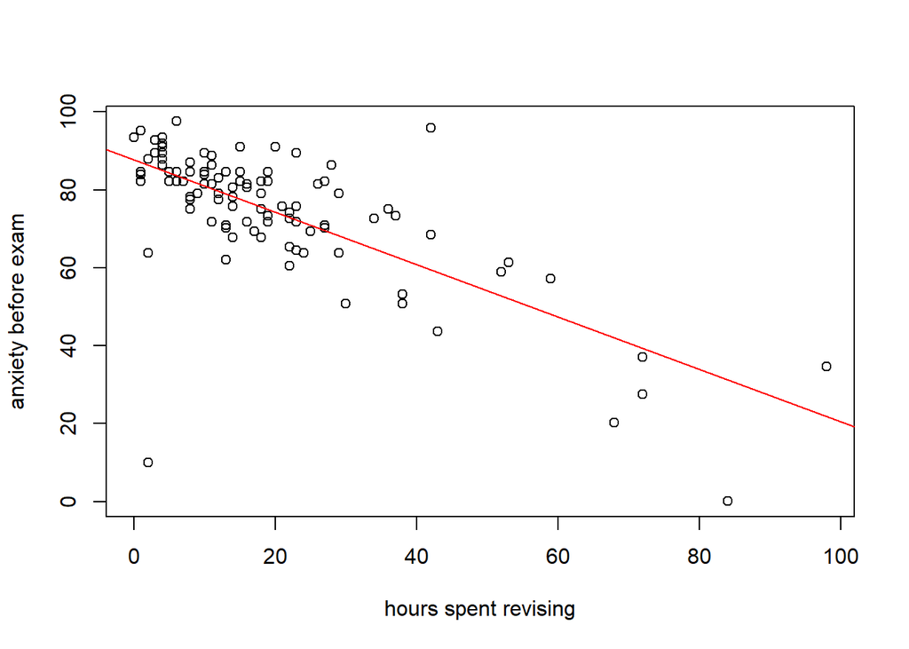

```r
plot( x = exam_anxiety_dat$hours_spent_revising,
      y = exam_anxiety_dat$anxiety_before_exam,
      xlab = "hours spent revising",
      ylab = "anxiety before exam"
    )
abline( lm(anxiety_before_exam~hours_spent_revising, data=exam_anxiety_dat), col=2 )
```

However, both **anxiety before exam** and **hours spent revising** are linearly associated with **exam score**:

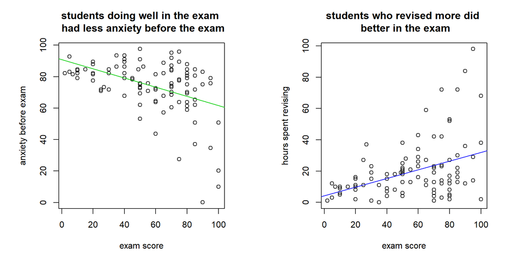

```r
par(mfrow=c(1,2), pty="s")
plot( x = exam_anxiety_dat$exam_score, y = exam_anxiety_dat$anxiety_before_exam,
      xlab = "exam score", ylab = "anxiety before exam",
      main = "students doing well in the exam \n had less anxiety before the exam")
abline( lm(anxiety_before_exam~exam_score, data=exam_anxiety_dat), col=3 )

plot( x = exam_anxiety_dat$exam_score, y = exam_anxiety_dat$hours_spent_revising,
      xlab = "exam score", ylab = "hours spent revising",
      main = "students who revised more did \n better in the exam")
abline( lm(hours_spent_revising~exam_score, data=exam_anxiety_dat), col=4 )
```

The partial correlation between **hours spent revising** and **exam anxiety**, controlling for the effect of **exam score** is -0.6485301, indicating that the negative relationship between these 2 variables is slightly less strong than previously measured (part of the apparent negative relationship between arose from each’s relationship to **exam score**)

```r
cor(
  residuals( lm(hours_spent_revising~exam_score, data=exam_anxiety_dat) )
  ,
  residuals( lm(anxiety_before_exam~exam_score, data=exam_anxiety_dat) )
)
```

```
## [1] -0.6485301
```

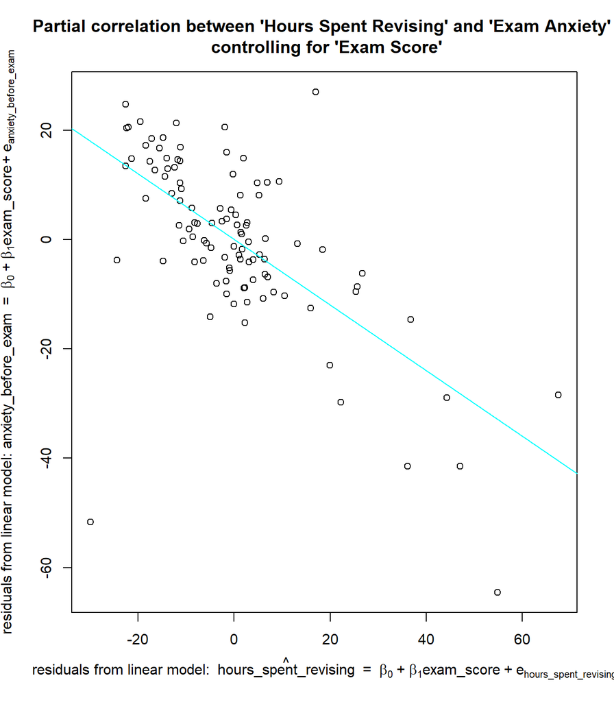

```r
plot( x = residuals( lm(hours_spent_revising~exam_score, data=exam_anxiety_dat) ),
      y = residuals( lm(anxiety_before_exam~exam_score, data=exam_anxiety_dat) ),
      xlab = bquote("residuals from linear model: "~hat(hours_spent_revising)~" = "~beta[0]~"+"~beta[1]*"exam_score"~"+"~e[hours_spent_revising]),
      ylab = bquote("residuals from linear model: "~hat(anxiety_before_exam)~" = "~beta[0]~"+"~beta[1]*"exam_score"~"+"~e[anxiety_before_exam]),
      main="Partial correlation between 'Hours Spent Revising' and 'Exam Anxiety' \n controlling for 'Exam Score'"
    )
abline( lm(y~x, data=data_frame(x=residuals( lm(hours_spent_revising~exam_score, data=exam_anxiety_dat) ),
                                y=residuals( lm(anxiety_before_exam~exam_score, data=exam_anxiety_dat) )
                              )
          ),
        col = 5
      )
```

$$\space$$

Similarly, we could calculate the partial correlation between **hours spent revising** and **anxiety before exam**, controlling for the effect of **exam score** and **gender**:

```r
cor(
  residuals( lm(hours_spent_revising~exam_score + factor(gender), data=exam_anxiety_dat) )
  ,
  residuals( lm(anxiety_before_exam~exam_score + factor(gender), data=exam_anxiety_dat) )
)
```

```
## [1] -0.6510138
```